# Data Info & Snippets

- Visual Python: Data Info & Snippets

#### 1. Data Info

1. General
   - Info
   - Describe
   - Head
   - Tail
2. Status
   - Null count
   - Duplicated
   - Unique
   - Value counts
3. Statistics
   - count, min, max, quantile, sum, mean, median, var, std, skew, kurtosis
   - cumsum
4. Correlation
   - Correlation table
   - Correlation matrix
5. Distribution
   - Histogram
   - Scatter matrix
   - Box plot
   - Count plot

#### 2. Snippets

# Import python package

```python
# Visual Python: Data Analysis > Import
import numpy as np
import pandas as pd
import matplotlib.pyplot as plt
%matplotlib inline
import seaborn as sns
```

# Load files

```python
# Visual Python: Data Analysis > File
df_iris = pd.read_csv('data/iris.csv')
df_iris
```

|  | sepal_length | sepal_width | petal_length | petal_width | variety |
| --- | --- | --- | --- | --- | --- |
| 0 | 5.1 | 3.5 | 1.4 | 0.2 | Setosa |
| 1 | 4.9 | 3.0 | 1.4 | 0.2 | Setosa |
| 2 | 4.7 | 3.2 | 1.3 | 0.2 | Setosa |
| 3 | 4.6 | 3.1 | 1.5 | 0.2 | Setosa |
| 4 | 5.0 | 3.6 | 1.4 | 0.2 | Setosa |
| ... | ... | ... | ... | ... | ... |
| 145 | 6.7 | 3.0 | 5.2 | 2.3 | Virginica |
| 146 | 6.3 | 2.5 | 5.0 | 1.9 | Virginica |
| 147 | 6.5 | 3.0 | 5.2 | 2.0 | Virginica |
| 148 | 6.2 | 3.4 | 5.4 | 2.3 | Virginica |
| 149 | 5.9 | 3.0 | 5.1 | 1.8 | Virginica |

150 rows × 5 columns

# 1. Data Info

## 1.1 General

### 1.1.1 Info

```python
# Visual Python: Data Analysis > Data Info
df_iris.info()
```

```
<class 'pandas.core.frame.DataFrame'>
RangeIndex: 150 entries, 0 to 149
Data columns (total 5 columns):
 #   Column        Non-Null Count  Dtype
---  ------        --------------  -----
 0   sepal_length  150 non-null    float64
 1   sepal_width   150 non-null    float64
 2   petal_length  150 non-null    float64
 3   petal_width   150 non-null    float64
 4   variety       150 non-null    object
dtypes: float64(4), object(1)
memory usage: 6.0+ KB
```

### 1.1.2 Describe

```python
# Visual Python: Data Analysis > Data Info
df_iris.describe()
```

|  | sepal_length | sepal_width | petal_length | petal_width |
| --- | --- | --- | --- | --- |
| count | 150.000000 | 150.000000 | 150.000000 | 150.000000 |
| mean | 5.843333 | 3.057333 | 3.758000 | 1.199333 |
| std | 0.828066 | 0.435866 | 1.765298 | 0.762238 |
| min | 4.300000 | 2.000000 | 1.000000 | 0.100000 |
| 25% | 5.100000 | 2.800000 | 1.600000 | 0.300000 |
| 50% | 5.800000 | 3.000000 | 4.350000 | 1.300000 |
| 75% | 6.400000 | 3.300000 | 5.100000 | 1.800000 |
| max | 7.900000 | 4.400000 | 6.900000 | 2.500000 |

### 1.1.3 Head

```python
# Visual Python: Data Analysis > Data Info
df_iris.head()
```

|  | sepal_length | sepal_width | petal_length | petal_width | variety |
| --- | --- | --- | --- | --- | --- |
| 0 | 5.1 | 3.5 | 1.4 | 0.2 | Setosa |
| 1 | 4.9 | 3.0 | 1.4 | 0.2 | Setosa |
| 2 | 4.7 | 3.2 | 1.3 | 0.2 | Setosa |
| 3 | 4.6 | 3.1 | 1.5 | 0.2 | Setosa |
| 4 | 5.0 | 3.6 | 1.4 | 0.2 | Setosa |

### 1.1.4 Tail

```python
# Visual Python: Data Analysis > Data Info
df_iris.tail()
```

|  | sepal_length | sepal_width | petal_length | petal_width | variety |
| --- | --- | --- | --- | --- | --- |
| 145 | 6.7 | 3.0 | 5.2 | 2.3 | Virginica |
| 146 | 6.3 | 2.5 | 5.0 | 1.9 | Virginica |
| 147 | 6.5 | 3.0 | 5.2 | 2.0 | Virginica |
| 148 | 6.2 | 3.4 | 5.4 | 2.3 | Virginica |
| 149 | 5.9 | 3.0 | 5.1 | 1.8 | Virginica |

## 1.2 Status

### 1.2.1 Null count

```python
# Visual Python: Data Analysis > Data Info
pd.DataFrame({'Null Count': df_iris.isnull().sum(), 'Non-Null Count': df_iris.notnull().sum()})
```

|  | Null Count | Non-Null Count |
| --- | --- | --- |
| sepal_length | 0 | 150 |
| sepal_width | 0 | 150 |
| petal_length | 0 | 150 |
| petal_width | 0 | 150 |
| variety | 0 | 150 |

```python
# Visual Python: Data Analysis > Data Info
df_iris.info() # info() 로도 간단하게 확인 가능
```

```
<class 'pandas.core.frame.DataFrame'>
RangeIndex: 150 entries, 0 to 149
Data columns (total 5 columns):
 #   Column        Non-Null Count  Dtype
---  ------        --------------  -----
 0   sepal_length  150 non-null    float64
 1   sepal_width   150 non-null    float64
 2   petal_length  150 non-null    float64
 3   petal_width   150 non-null    float64
 4   variety       150 non-null    object
dtypes: float64(4), object(1)
memory usage: 6.0+ KB
```

### 1.2.2 Duplicated

```python
# Visual Python: Data Analysis > Data Info
_duplicated = ([df_iris.duplicated().sum()] + [df_iris[col].duplicated().sum() for col in df_iris.columns])
_duplicated_df = pd.DataFrame({
    'Rows':[len(df_iris)]*len(_duplicated),
    'Unique':[len(df_iris) - dups for dups in _duplicated],
    'Duplicated': _duplicated,
    'Duplicated by': ['All columns'] + df_iris.columns.to_list()
}, index=['Combination']+df_iris.columns.to_list())
_duplicated_df
```

|  | Rows | Unique | Duplicated | Duplicated by |
| --- | --- | --- | --- | --- |
| Combination | 150 | 149 | 1 | All columns |
| sepal_length | 150 | 35 | 115 | sepal_length |
| sepal_width | 150 | 23 | 127 | sepal_width |
| petal_length | 150 | 43 | 107 | petal_length |
| petal_width | 150 | 22 | 128 | petal_width |
| variety | 150 | 3 | 147 | variety |

### 1.2.3 Unique

```python
# Visual Python: Data Analysis > Data Info
df_iris['variety'].unique()
```

```
array(['Setosa', 'Versicolor', 'Virginica'], dtype=object)
```

### 1.2.4 Value counts

```python
# Visual Python: Library > value_counts
df_iris['variety'].value_counts()
```

```
Setosa        50
Versicolor    50
Virginica     50
Name: variety, dtype: int64
```

```python
# Visual Python: Library > value_counts
df_iris['sepal_width'].value_counts(bins=5)
```

```
(2.96, 3.44]     68
(2.48, 2.96]     46
(3.44, 3.92]     21
(1.997, 2.48]    11
(3.92, 4.4]       4
Name: sepal_width, dtype: int64
```

```python
# Visual Python: Data Analysis > Data Info
_dfr = pd.DataFrame()
for col in df_iris.columns:
    if pd.api.types.is_numeric_dtype(df_iris[col]) and  df_iris[col].value_counts().size > 10:
        _value_counts = df_iris[col].value_counts(bins=10, sort=False)
        _dfr = pd.concat([_dfr, pd.DataFrame({(col,'bins'): _value_counts.index})], axis=1)
    else:
        _value_counts = df_iris[col].value_counts()
        _dfr = pd.concat([_dfr, pd.DataFrame({(col,'category'): _value_counts.index})], axis=1)
    _dfr = pd.concat([_dfr, pd.DataFrame({(col,'count'): _value_counts.values})], axis=1)
_dfr.replace(np.nan,'')
```

|  | sepal_length bins | sepal_length count | sepal_width bins | sepal_width count | petal_length bins | petal_length count | petal_width bins | petal_width count | variety category | variety count |
| --- | --- | --- | --- | --- | --- | --- | --- | --- | --- | --- |
| 0 | (4.295, 4.66] | 9 | (1.997, 2.24] | 4 | (0.993, 1.59] | 37 | (0.0966, 0.34] | 41 | Setosa | 50.0 |
| 1 | (4.66, 5.02] | 23 | (2.24, 2.48] | 7 | (1.59, 2.18] | 13 | (0.34, 0.58] | 8 | Versicolor | 50.0 |
| 2 | (5.02, 5.38] | 14 | (2.48, 2.72] | 22 | (2.18, 2.77] | 0 | (0.58, 0.82] | 1 | Virginica | 50.0 |
| 3 | (5.38, 5.74] | 27 | (2.72, 2.96] | 24 | (2.77, 3.36] | 3 | (0.82, 1.06] | 7 |  |  |
| 4 | (5.74, 6.1] | 22 | (2.96, 3.2] | 50 | (3.36, 3.95] | 8 | (1.06, 1.3] | 21 |  |  |
| 5 | (6.1, 6.46] | 20 | (3.2, 3.44] | 18 | (3.95, 4.54] | 26 | (1.3, 1.54] | 20 |  |  |
| 6 | (6.46, 6.82] | 18 | (3.44, 3.68] | 10 | (4.54, 5.13] | 29 | (1.54, 1.78] | 6 |  |  |
| 7 | (6.82, 7.18] | 6 | (3.68, 3.92] | 11 | (5.13, 5.72] | 18 | (1.78, 2.02] | 23 |  |  |
| 8 | (7.18, 7.54] | 5 | (3.92, 4.16] | 2 | (5.72, 6.31] | 11 | (2.02, 2.26] | 9 |  |  |
| 9 | (7.54, 7.9] | 6 | (4.16, 4.4] | 2 | (6.31, 6.9] | 5 | (2.26, 2.5] | 14 |  |  |

## 1.3 Statistics

### 1.3.1 count, min, max, quantile, sum, mean, median, var, std, skew, kurtosis

```python
# Visual Python: Data Analysis > Data Info
pd.DataFrame({'count': df_iris.count(),'min': df_iris.min(numeric_only=True),'max': df_iris.max(numeric_only=True),'quantile': df_iris.quantile(numeric_only=True),'sum': df_iris.sum(numeric_only=True),'mean': df_iris.mean(numeric_only=True),'median': df_iris.median(numeric_only=True),'var': df_iris.var(numeric_only=True),'std': df_iris.std(numeric_only=True),'skew': df_iris.skew(numeric_only=True),'kurtosis': df_iris.kurtosis(numeric_only=True)})
```

|  | count | min | max | quantile | sum | mean | median | var | std | skew | kurtosis |
| --- | --- | --- | --- | --- | --- | --- | --- | --- | --- | --- | --- |
| petal_length | 150 | 1.0 | 6.9 | 4.35 | 563.7 | 3.758000 | 4.35 | 3.116278 | 1.765298 | -0.274884 | -1.402103 |
| petal_width | 150 | 0.1 | 2.5 | 1.30 | 179.9 | 1.199333 | 1.30 | 0.581006 | 0.762238 | -0.102967 | -1.340604 |
| sepal_length | 150 | 4.3 | 7.9 | 5.80 | 876.5 | 5.843333 | 5.80 | 0.685694 | 0.828066 | 0.314911 | -0.552064 |
| sepal_width | 150 | 2.0 | 4.4 | 3.00 | 458.6 | 3.057333 | 3.00 | 0.189979 | 0.435866 | 0.318966 | 0.228249 |
| variety | 150 | NaN | NaN | NaN | NaN | NaN | NaN | NaN | NaN | NaN | NaN |

### 1.3.2 cumsum

```python
# Visual Python: Data Analysis > Data Info
df_iris[['sepal_length','sepal_width','petal_length','petal_width']].cumsum()
```

|  | sepal_length | sepal_width | petal_length | petal_width |
| --- | --- | --- | --- | --- |
| 0 | 5.1 | 3.5 | 1.4 | 0.2 |
| 1 | 10.0 | 6.5 | 2.8 | 0.4 |
| 2 | 14.7 | 9.7 | 4.1 | 0.6 |
| 3 | 19.3 | 12.8 | 5.6 | 0.8 |
| 4 | 24.3 | 16.4 | 7.0 | 1.0 |
| ... | ... | ... | ... | ... |
| 145 | 851.6 | 446.7 | 543.0 | 171.9 |
| 146 | 857.9 | 449.2 | 548.0 | 173.8 |
| 147 | 864.4 | 452.2 | 553.2 | 175.8 |
| 148 | 870.6 | 455.6 | 558.6 | 178.1 |
| 149 | 876.5 | 458.6 | 563.7 | 179.9 |

150 rows × 4 columns

## 1.4 Correlation

### 1.4.1 Correlation table

```python
# Visual Python: Data Analysis > Data Info
df_iris.corr(numeric_only=True)
```

|  | sepal_length | sepal_width | petal_length | petal_width |
| --- | --- | --- | --- | --- |
| sepal_length | 1.000000 | -0.117570 | 0.871754 | 0.817941 |
| sepal_width | -0.117570 | 1.000000 | -0.428440 | -0.366126 |
| petal_length | 0.871754 | -0.428440 | 1.000000 | 0.962865 |
| petal_width | 0.817941 | -0.366126 | 0.962865 | 1.000000 |

### 1.4.1 Correlation matrix

```python
# Visual Python: Data Analysis > Data Info
_corr = df_iris.corr(numeric_only=True)
_corr.style.background_gradient(cmap='coolwarm')
```

|  | sepal_length | sepal_width | petal_length | petal_width |
| --- | --- | --- | --- | --- |
| sepal_length | 1.000000 | -0.117570 | 0.871754 | 0.817941 |
| sepal_width | -0.117570 | 1.000000 | -0.428440 | -0.366126 |
| petal_length | 0.871754 | -0.428440 | 1.000000 | 0.962865 |
| petal_width | 0.817941 | -0.366126 | 0.962865 | 1.000000 |

## 1.5 Distribution

### 1.5.1 Histogram

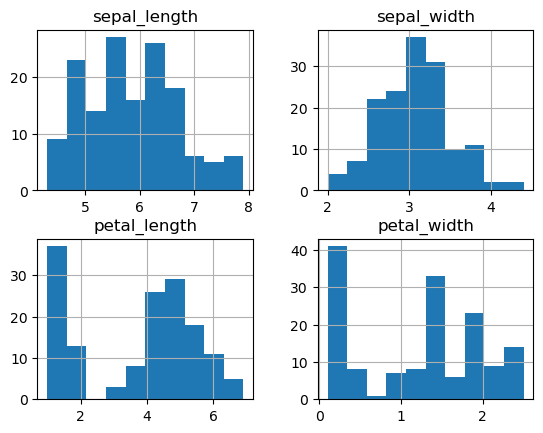

```python
# Visual Python: Data Analysis > Data Info
df_iris.hist()
plt.show()
```

### 1.5.2 Scatter matrix

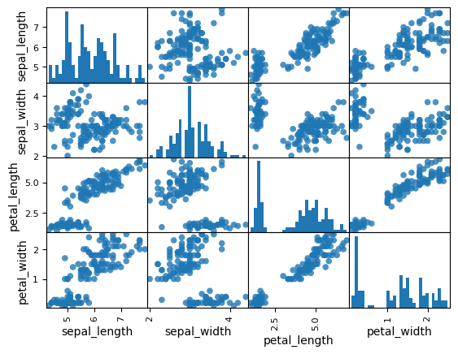

```python
# Visual Python: Data Analysis > Data Info
pd.plotting.scatter_matrix(df_iris, marker='o', hist_kwds={'bins': 30}, s=30, alpha=.8)
plt.show()
```

### 1.5.3 Box plot

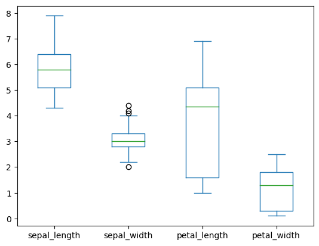

```python
# Visual Python: Data Analysis > Data Info
df_iris.plot(kind='box')
plt.show()
```

### 1.5.4 Count plot

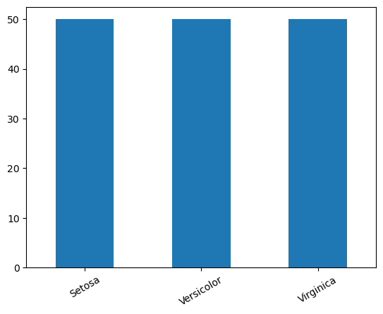

```python
# Visual Python: Data Analysis > Data Info
df_iris['variety'].value_counts().plot(kind='bar', rot=30)
plt.show()
```

# 2. Snippets

```python
# Visual Python: Data Analysis > Snippets
def as_int(x):
    """
    usage: df['col'] = df['col'].apply(as_int)
    """
    if not isinstance(x, str):
        return 0
    else:
        try:
            result = int(x)
            return result
        except ValueError:
            return 0.0
```

```python
# Visual Python: Data Analysis > Snippets
def as_int(x):
    """
    usage: df['col'] = df['col'].apply(as_int)
    """
    if not isinstance(x, str):
        return 0
    else:
        try:
            result = int(x)
            return result
        except ValueError:
            return 0.0
```

# [실습] 직접 해보기

## 실습 1. Titanic 데이터로 Data Info 실습하기

```python
# Visual Python: Data Analysis > File
df_titanic = pd.read_csv('./data/titanic.csv')
df_titanic
```

|  | PassengerId | Survived | Pclass | Name | Sex | Age | SibSp | Parch | Ticket | Fare | Cabin | Embarked |
| --- | --- | --- | --- | --- | --- | --- | --- | --- | --- | --- | --- | --- |
| 0 | 1 | 0 | 3 | Braund, Mr. Owen Harris | male | 22.0 | 1 | 0 | A/5 21171 | 7.2500 | NaN | S |
| 1 | 2 | 1 | 1 | Cumings, Mrs. John Bradley (Florence Briggs Th... | female | 38.0 | 1 | 0 | PC 17599 | 71.2833 | C85 | C |
| 2 | 3 | 1 | 3 | Heikkinen, Miss. Laina | female | 26.0 | 0 | 0 | STON/O2. 3101282 | 7.9250 | NaN | S |
| 3 | 4 | 1 | 1 | Futrelle, Mrs. Jacques Heath (Lily May Peel) | female | 35.0 | 1 | 0 | 113803 | 53.1000 | C123 | S |
| 4 | 5 | 0 | 3 | Allen, Mr. William Henry | male | 35.0 | 0 | 0 | 373450 | 8.0500 | NaN | S |
| ... | ... | ... | ... | ... | ... | ... | ... | ... | ... | ... | ... | ... |
| 886 | 887 | 0 | 2 | Montvila, Rev. Juozas | male | 27.0 | 0 | 0 | 211536 | 13.0000 | NaN | S |
| 887 | 888 | 1 | 1 | Graham, Miss. Margaret Edith | female | 19.0 | 0 | 0 | 112053 | 30.0000 | B42 | S |
| 888 | 889 | 0 | 3 | Johnston, Miss. Catherine Helen "Carrie" | female | NaN | 1 | 2 | W./C. 6607 | 23.4500 | NaN | S |
| 889 | 890 | 1 | 1 | Behr, Mr. Karl Howell | male | 26.0 | 0 | 0 | 111369 | 30.0000 | C148 | C |
| 890 | 891 | 0 | 3 | Dooley, Mr. Patrick | male | 32.0 | 0 | 0 | 370376 | 7.7500 | NaN | Q |

891 rows × 12 columns

#### Q. titanic 데이터의 각 컬럼별 dtype과 데이터의 행 개수를 출력하세요.

```python
# Visual Python: Data Analysis > Data Info
df_titanic.info()
```

```
<class 'pandas.core.frame.DataFrame'>
RangeIndex: 891 entries, 0 to 890
Data columns (total 12 columns):
 #   Column       Non-Null Count  Dtype
---  ------       --------------  -----
 0   PassengerId  891 non-null    int64
 1   Survived     891 non-null    int64
 2   Pclass       891 non-null    int64
 3   Name         891 non-null    object
 4   Sex          891 non-null    object
 5   Age          714 non-null    float64
 6   SibSp        891 non-null    int64
 7   Parch        891 non-null    int64
 8   Ticket       891 non-null    object
 9   Fare         891 non-null    float64
 10  Cabin        204 non-null    object
 11  Embarked     889 non-null    object
dtypes: float64(2), int64(5), object(5)
memory usage: 83.7+ KB
```

#### Q. 데이터를 대략적으로 파악하기 위해, 위에서부터 5개 행을 출력하고, 아래에서부터 5개 행을 출력하세요.

```python
# Visual Python: Data Analysis > Data Info
df_titanic.head()
```

|  | PassengerId | Survived | Pclass | Name | Sex | Age | SibSp | Parch | Ticket | Fare | Cabin | Embarked |
| --- | --- | --- | --- | --- | --- | --- | --- | --- | --- | --- | --- | --- |
| 0 | 1 | 0 | 3 | Braund, Mr. Owen Harris | male | 22.0 | 1 | 0 | A/5 21171 | 7.2500 | NaN | S |
| 1 | 2 | 1 | 1 | Cumings, Mrs. John Bradley (Florence Briggs Th... | female | 38.0 | 1 | 0 | PC 17599 | 71.2833 | C85 | C |
| 2 | 3 | 1 | 3 | Heikkinen, Miss. Laina | female | 26.0 | 0 | 0 | STON/O2. 3101282 | 7.9250 | NaN | S |
| 3 | 4 | 1 | 1 | Futrelle, Mrs. Jacques Heath (Lily May Peel) | female | 35.0 | 1 | 0 | 113803 | 53.1000 | C123 | S |
| 4 | 5 | 0 | 3 | Allen, Mr. William Henry | male | 35.0 | 0 | 0 | 373450 | 8.0500 | NaN | S |

```python
# Visual Python: Data Analysis > Data Info
df_titanic.tail()
```

|  | PassengerId | Survived | Pclass | Name | Sex | Age | SibSp | Parch | Ticket | Fare | Cabin | Embarked |
| --- | --- | --- | --- | --- | --- | --- | --- | --- | --- | --- | --- | --- |
| 886 | 887 | 0 | 2 | Montvila, Rev. Juozas | male | 27.0 | 0 | 0 | 211536 | 13.00 | NaN | S |
| 887 | 888 | 1 | 1 | Graham, Miss. Margaret Edith | female | 19.0 | 0 | 0 | 112053 | 30.00 | B42 | S |
| 888 | 889 | 0 | 3 | Johnston, Miss. Catherine Helen "Carrie" | female | NaN | 1 | 2 | W./C. 6607 | 23.45 | NaN | S |
| 889 | 890 | 1 | 1 | Behr, Mr. Karl Howell | male | 26.0 | 0 | 0 | 111369 | 30.00 | C148 | C |
| 890 | 891 | 0 | 3 | Dooley, Mr. Patrick | male | 32.0 | 0 | 0 | 370376 | 7.75 | NaN | Q |

#### Q. 타이타닉호 탑승자의 `Age`와 `Fare`의 최소값, 최대값, 평균, 중앙값을 출력하세요.

> **💡 Visual Python Tip**  
> Ctrl 키와 마우스 좌클릭으로 여러개의 컬럼을 선택할 수 있습니다. 또한, Shift 키와 마우스 좌클릭으로 연속된 컬럼을 선택할 수 있습니다.

```python
# Visual Python: Data Analysis > Data Info
pd.DataFrame({'min': df_titanic[['Age','Fare']].min(numeric_only=True),'max': df_titanic[['Age','Fare']].max(numeric_only=True),'mean': df_titanic[['Age','Fare']].mean(numeric_only=True),'median': df_titanic[['Age','Fare']].median(numeric_only=True)})
```

|  | min | max | mean | median |
| --- | --- | --- | --- | --- |
| Age | 0.42 | 80.0000 | 29.699118 | 28.0000 |
| Fare | 0.00 | 512.3292 | 32.204208 | 14.4542 |

#### Q. 데이터의 각 컬럼별 결측치 개수를 출력하세요.

```python
# Visual Python: Data Analysis > Data Info
pd.DataFrame({'Null Count': df_titanic.isnull().sum(), 'Non-Null Count': df_titanic.notnull().sum()})
```

|  | Null Count | Non-Null Count |
| --- | --- | --- |
| PassengerId | 0 | 891 |
| Survived | 0 | 891 |
| Pclass | 0 | 891 |
| Name | 0 | 891 |
| Sex | 0 | 891 |
| Age | 177 | 714 |
| SibSp | 0 | 891 |
| Parch | 0 | 891 |
| Ticket | 0 | 891 |
| Fare | 0 | 891 |
| Cabin | 687 | 204 |
| Embarked | 2 | 889 |

#### Q. 컬럼별 중복된 행의 개수를 확인하세요.

```python
# Visual Python: Data Analysis > Data Info
_duplicated = ([df_titanic.duplicated().sum()] + [df_titanic[col].duplicated().sum() for col in df_titanic.columns])
_duplicated_df = pd.DataFrame({
    'Rows':[len(df_titanic)]*len(_duplicated),
    'Unique':[len(df_titanic) - dups for dups in _duplicated],
    'Duplicated': _duplicated,
    'Duplicated by': ['All columns'] + df_titanic.columns.to_list()
}, index=['Combination']+df_titanic.columns.to_list())
_duplicated_df
```

|  | Rows | Unique | Duplicated | Duplicated by |
| --- | --- | --- | --- | --- |
| Combination | 891 | 891 | 0 | All columns |
| PassengerId | 891 | 891 | 0 | PassengerId |
| Survived | 891 | 2 | 889 | Survived |
| Pclass | 891 | 3 | 888 | Pclass |
| Name | 891 | 891 | 0 | Name |
| Sex | 891 | 2 | 889 | Sex |
| Age | 891 | 89 | 802 | Age |
| SibSp | 891 | 7 | 884 | SibSp |
| Parch | 891 | 7 | 884 | Parch |
| Ticket | 891 | 681 | 210 | Ticket |
| Fare | 891 | 248 | 643 | Fare |
| Cabin | 891 | 148 | 743 | Cabin |
| Embarked | 891 | 4 | 887 | Embarked |

#### Q. 중복된 값을 출력한 결과에서, `Unique`값이 5 이하인 컬럼들에 대해 몇 가지 카테고리로 구분되어 있고, 각 카테고리별 데이터의 수를 출력하세요.

```python
# Visual Python: Data Analysis > Data Info
_dfr = pd.DataFrame()
for col in df_titanic[['Survived','Pclass','Sex','Embarked']].columns:
    if pd.api.types.is_numeric_dtype(df_titanic[['Survived','Pclass','Sex','Embarked']][col]) and  df_titanic[['Survived','Pclass','Sex','Embarked']][col].value_counts().size > 10:
        _value_counts = df_titanic[['Survived','Pclass','Sex','Embarked']][col].value_counts(bins=10, sort=False)
        _dfr = pd.concat([_dfr, pd.DataFrame({(col,'bins'): _value_counts.index})], axis=1)
    else:
        _value_counts = df_titanic[['Survived','Pclass','Sex','Embarked']][col].value_counts()
        _dfr = pd.concat([_dfr, pd.DataFrame({(col,'category'): _value_counts.index})], axis=1)
    _dfr = pd.concat([_dfr, pd.DataFrame({(col,'count'): _value_counts.values})], axis=1)
_dfr.replace(np.nan,'')
```

|  | Survived category | Survived count | Pclass category | Pclass count | Sex category | Sex count | Embarked category | Embarked count |
| --- | --- | --- | --- | --- | --- | --- | --- | --- |
| 0 | 0.0 | 549.0 | 3 | 491 | male | 577.0 | S | 644 |
| 1 | 1.0 | 342.0 | 1 | 216 | female | 314.0 | C | 168 |
| 2 |  |  | 2 | 184 |  |  | Q | 77 |

#### Q. 수치형인 `Fare` 컬럼의 히스토그램을 출력해 분포를 확인하세요.

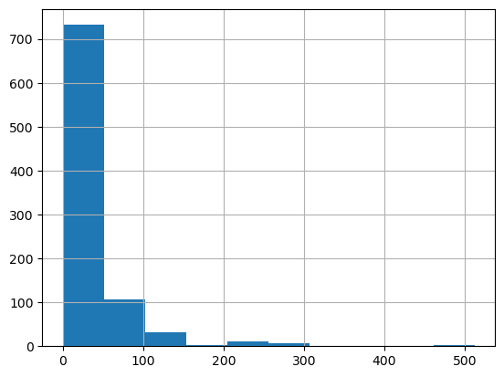

```python
# Visual Python: Data Analysis > Data Info
df_titanic['Fare'].hist()
plt.show()
```

#### Q. 데이터의 수치형 컬럼들 간 상관계수를 구하시오.

```python
# Visual Python: Data Analysis > Data Info
df_titanic.corr(numeric_only=True)
```

|  | PassengerId | Survived | Pclass | Age | SibSp | Parch | Fare |
| --- | --- | --- | --- | --- | --- | --- | --- |
| PassengerId | 1.000000 | -0.005007 | -0.035144 | 0.036847 | -0.057527 | -0.001652 | 0.012658 |
| Survived | -0.005007 | 1.000000 | -0.338481 | -0.077221 | -0.035322 | 0.081629 | 0.257307 |
| Pclass | -0.035144 | -0.338481 | 1.000000 | -0.369226 | 0.083081 | 0.018443 | -0.549500 |
| Age | 0.036847 | -0.077221 | -0.369226 | 1.000000 | -0.308247 | -0.189119 | 0.096067 |
| SibSp | -0.057527 | -0.035322 | 0.083081 | -0.308247 | 1.000000 | 0.414838 | 0.159651 |
| Parch | -0.001652 | 0.081629 | 0.018443 | -0.189119 | 0.414838 | 1.000000 | 0.216225 |
| Fare | 0.012658 | 0.257307 | -0.549500 | 0.096067 | 0.159651 | 0.216225 | 1.000000 |

#### Q. [심화] `Survived`와 나머지 수치형 컬럼들 간 상관계수를 구하시오. 단, 상관계수를 내림차순으로 정렬해서 표시하시오.

> **💡 Visual Python Tip**  
> Instance 앱을 통해 다양한 속성과 함수를 활용할 수 있습니다.다.

```python
# Visual Python: Data Analysis > Instance
df_titanic.corr(numeric_only=True).loc[:, 'Survived'].sort_values(ascending=False)
```

```
Survived       1.000000
Fare           0.257307
Parch          0.081629
PassengerId   -0.005007
SibSp         -0.035322
Age           -0.077221
Pclass        -0.338481
Name: Survived, dtype: float64
```

```python
# End of file
```